# Explorative Data Analysis

## Investegating

Plotting each variable individually.

```r
Plot1 <-  data_Carlsberg  %>% ggplot(aes(y = Carlsberg, x = Date,  col= "red") ) + geom_line()  + theme(legend.position = "none")  + labs(y="" ,x = "Carlsberg")

Plot2 <-  data_Carlsberg %>% ggplot(aes(y = DSV, x = Date)) + geom_line(col= "skyblue") + theme(legend.position = "none") + labs(y="", x = "DSV")

Plot3 <-  data_Carlsberg %>%   ggplot(aes(y = GN, x = Date)) + geom_line(col= "darkgreen") + theme(legend.position = "none") + labs(y="", x = " GN")

Plot4 <-  data_Carlsberg %>%   ggplot(aes(y = JyskeBank, x = Date)) + geom_line(col= "darkolivegreen4") + theme(legend.position = "none") + labs(y="", x = "JyskeBank")

Plot5 <-  data_Carlsberg %>% ggplot(aes(y = Tryg, x = Date)) + geom_line(col = "deepskyblue4") + theme(legend.position = "none")     + labs(y="", x = "Tryg")

Plot6 <-  data_Carlsberg %>% ggplot(aes(y =OilPrice, x = Date)) + geom_line(col = "deepskyblue3") + theme(legend.position = "none")     + labs(y="" ,x = "Oil Price")
```

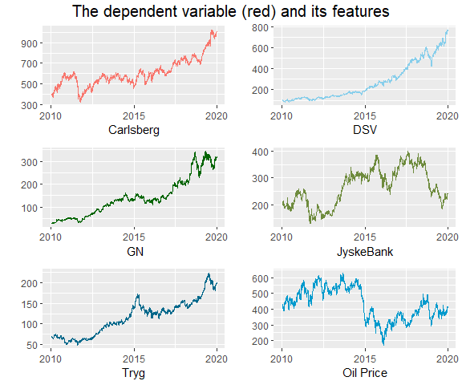

```r
Plot_Collected<-ggarrange(Plot1, Plot2, Plot3, Plot4, Plot5, Plot6, ncol = 2, nrow = 3)
annotate_figure(Plot_Collected, top = text_grob("The dependent variable (red) and its features", size = 15))
```

### Boxplot

Creating a summary in order to investigate each variable.

```r
data_Carlsberg %>% select(-Date) %>%  summary()
```

```
   Carlsberg           DSV              GN           JyskeBank          Tryg
 Min.   : 322.2   Min.   : 83.5   Min.   : 28.40   Min.   :131.3   Min.   : 48.66
 1st Qu.: 524.1   1st Qu.:128.9   1st Qu.: 72.42   1st Qu.:206.9   1st Qu.: 71.40
 Median : 581.0   Median :189.3   Median :131.10   Median :269.4   Median :122.65
 Mean   : 607.2   Mean   :274.3   Mean   :142.28   Mean   :267.3   Mean   :115.68
 3rd Qu.: 692.2   3rd Qu.:404.2   3rd Qu.:193.93   3rd Qu.:321.5   3rd Qu.:143.50
 Max.   :1025.5   Max.   :771.0   Max.   :342.90   Max.   :398.0   Max.   :224.00
    OilPrice
 Min.   :172.3
 1st Qu.:348.6
 Median :433.9
 Mean   :431.2
 3rd Qu.:525.7
 Max.   :629.0
```

Creating a box plot for each variable. (I created two boxplot because I am not sure which one to pick).

```r
Plot1 <-  data_Carlsberg %>% ggplot(aes(y = Carlsberg, x = Date,  col= "red") ) +   geom_boxplot()  + theme(legend.position = "none") + labs(y="" ,x = "Carlsberg")

Plot2 <-  data_Carlsberg  %>% ggplot(aes(y = DSV, x = Date)) + geom_boxplot(col= "skyblue") + theme(legend.position = "none")  + labs(y="", x = "DSV")

Plot3 <-  data_Carlsberg %>%ggplot(aes(y = GN, x = Date)) + geom_boxplot(col= "darkgreen") + theme(legend.position = "none") + labs(y="", x = " GN")

Plot4 <-  data_Carlsberg %>% ggplot(aes(y = JyskeBank, x = Date)) + geom_boxplot(col= "darkolivegreen4") + theme(legend.position = "none") + labs(y="", x = "JyskeBank")

Plot5 <-  data_Carlsberg %>% ggplot(aes(y = Tryg, x = Date)) + geom_boxplot(col = "deepskyblue4") + theme(legend.position = "none")     + labs(y="", x = "Tryg")

Plot6 <- data_Carlsberg %>% ggplot(aes(y =OilPrice, x = Date)) + geom_boxplot(col = "deepskyblue3") + theme(legend.position = "none")     + labs(y="" ,x = "Oil Price")
```

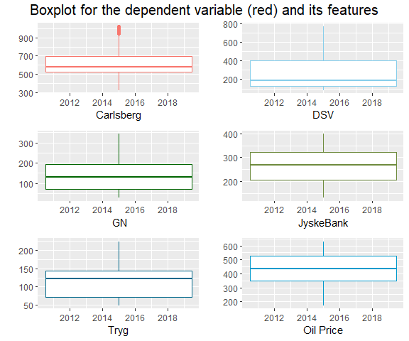

```r
Plot_Collected<-ggarrange(Plot1, Plot2, Plot3, Plot4, Plot5, Plot6, ncol = 2, nrow = 3)
annotate_figure(Plot_Collected, top = text_grob("Boxplot for the dependent variable (red) and its features", size = 15))
```

When plotting the date by using the *gather* function, the stocks is plotted in alphabetic order. To get the same order as the other plots, the plots is recorded into a number and a factor, then the number is given a level, and then given a number is given a label corresponding the name of the company.

```r
data_Carlsberg_plot<- gather(data_Carlsberg, Company, Value, -Date)
data_Carlsberg_plot %<>% mutate(Company = ifelse(Company == "Carlsberg", 1,
                           ifelse(Company == "DSV", 2,
                           ifelse(Company == "GN", 3,
                           ifelse(Company == "JyskeBank", 4,
                           ifelse(Company == "Tryg", 5,
                           ifelse(Company == "OilPrice", 6, "test")))))))
data_Carlsberg_plot$Company <- factor(as.numeric(data_Carlsberg_plot$Company),
          levels = c(1, 2, 3, 4, 5, 6),
          labels = c("Carlsberg", "DSV", "GN", "Jyske Bank", "Tryg", "Oil Price"))
```

The second box plot.

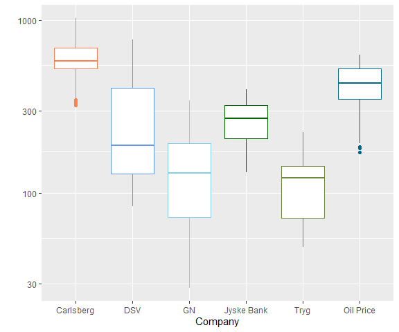

```r
data_Carlsberg_plot%>%
ggplot( aes(x=Company, y=Value)) + geom_boxplot(col = c("coral", "cornflowerblue", "skyblue","darkgreen", "darkolivegreen4", "deepskyblue4"))+ scale_y_log10()  + labs(y="", x = "Company")
```

A yearly boxplot is made for each variable. This shows if the rise/fall the stock did a year were distributed on a few observation or were more consistent.

```r
Plot1 <- data_Carlsberg %>% select(Date, Carlsberg) %>%mutate(Year = format(Date, "%Y" )) %>%  ggplot(aes(x=Year, y=Carlsberg)) + geom_boxplot(col = "coral")+ theme(legend.position = "none") + labs(y="" ,x = "Carlsberg")

Plot2 <-  data_Carlsberg  %>% select(Date, DSV) %>%mutate(Year = format(Date, "%Y" )) %>% ggplot(aes(x = Year, y = DSV)) + geom_boxplot(col= "skyblue") + theme(legend.position = "none")  + labs(y="", x = "DSV")

Plot3 <-  data_Carlsberg %>%select(Date, GN) %>%mutate(Year = format(Date, "%Y" )) %>% ggplot(aes(x = Year, y = GN)) + geom_boxplot(col= "darkgreen") + theme(legend.position = "none") + labs(y="", x = " GN")

Plot4 <-  data_Carlsberg %>%select(Date, JyskeBank) %>% mutate(Year = format(Date, "%Y" )) %>% ggplot(aes(x = Year, y = JyskeBank)) + geom_boxplot(col= "darkolivegreen4") + theme(legend.position = "none") + labs(y="", x = "Jyske Bank")

Plot5 <-  data_Carlsberg%>%select(Date, Tryg) %>% mutate(Year = format(Date, "%Y" )) %>% ggplot(aes(x = Year, y = Tryg)) + geom_boxplot(col = "deepskyblue4") + theme(legend.position = "none")     + labs(y="", x = "Tryg")

Plot6 <-  data_Carlsberg%>%select(Date, OilPrice) %>% mutate(Year = format(Date, "%Y" )) %>% ggplot(aes(x = Year, y =OilPrice)) + geom_boxplot(col = "deepskyblue3") + theme(legend.position = "none")     + labs(y="" ,x = "Oil Price")
```

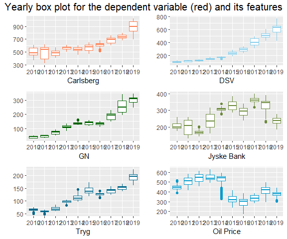

```r
Plot_Collected<-ggarrange(Plot1, Plot2, Plot3, Plot4, Plot5, Plot6, ncol = 2, nrow = 3)
annotate_figure(Plot_Collected, top = text_grob("Yearly box plot for the dependent variable (red) and its features", size = 15))
```

### Density plot

Plotting a density plot and the mean for each variable.

```r
Plot1 <-  data_Carlsberg %>% ggplot(aes(x = Carlsberg, col= "red") ) +   geom_density()  + theme(legend.position = "none")+ geom_vline(aes(xintercept=mean(Carlsberg)),
            color="darkgrey", linetype="dashed", size=1) + labs(y="" ,x = "Carlsberg")

Plot2 <-  data_Carlsberg  %>% ggplot(aes(x = DSV)) + geom_density(col= "skyblue") + theme(legend.position = "none")+ geom_vline(aes(xintercept=mean(DSV)),
            color="darkgrey", linetype="dashed", size=1)   + labs(y="", x = "DSV")

Plot3 <-  data_Carlsberg %>%ggplot(aes(x = GN)) + geom_density(col= "darkgreen") + theme(legend.position = "none")+ geom_vline(aes(xintercept=mean(GN)),
            color="darkgrey", linetype="dashed", size=1) + labs(y="", x = "GN")

Plot4 <-  data_Carlsberg %>% ggplot(aes(x = JyskeBank)) + geom_density(col= "darkolivegreen4") + theme(legend.position = "none")+ geom_vline(aes(xintercept=mean(JyskeBank)),
            color="darkgrey", linetype="dashed", size=1) + labs(y="", x = "Jyske Bank")

Plot5 <-  data_Carlsberg %>% ggplot(aes(x = Tryg)) + geom_density(col = "deepskyblue4") + theme(legend.position = "none") +geom_vline(aes(xintercept=mean(Tryg)),
            color="darkgrey", linetype="dashed", size=1) + labs(y="", x = "Tryg")

Plot6 <-  data_Carlsberg %>% ggplot(aes(x =OilPrice)) + geom_density(col = "deepskyblue3") + geom_vline(aes(xintercept=mean(OilPrice)),
            color="darkgrey", linetype="dashed", size=1) + theme(legend.position = "none")     + labs(y="" ,x = "Oil Price")
```

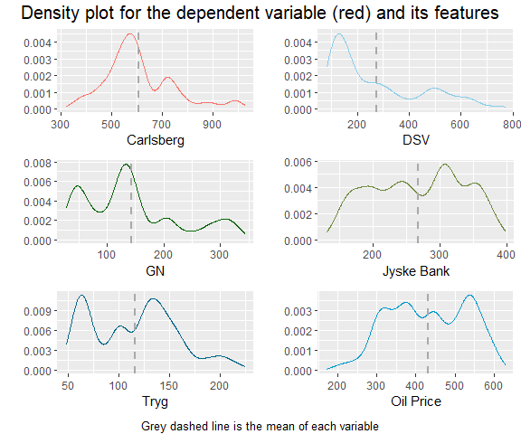

```r
Plot_Collected<-ggarrange(Plot1, Plot2, Plot3, Plot4, Plot5, Plot6, ncol = 2, nrow = 3)
annotate_figure(Plot_Collected, top = text_grob("Density plot for the dependent variable (red) and its features", size = 15),  bottom = text_grob("Grey dashed line is the mean of each variable", size = 10))
```

## The change in stock

Creating a new data set for change in price in per cent.

```r
data_Carlsberg_Change <- data_Carlsberg %>%
  mutate(Carlsberg  = ((Carlsberg-lag(Carlsberg))/lag(Carlsberg))*100,
         DSV = ((DSV-lag(DSV))/lag(DSV))*100,
         GN = ((GN-lag(GN))/lag(GN))*100,
         JyskeBank = ((JyskeBank-lag(JyskeBank))/lag(JyskeBank))*100,
         Tryg = ((Tryg-lag(Tryg))/lag(Tryg))*100,
         OilPrice = ((OilPrice-lag(OilPrice))/lag(OilPrice))*100) %>%
         drop_na()
```

Plotting the change in per cent for each variable individually. This shows how volatile each variable is.

```r
Plot1 <-  data_Carlsberg_Change  %>% ggplot(aes(y = Carlsberg, x = Date,  col= "red") ) + geom_line()  + theme(legend.position = "none")  + labs(y="" ,x = "Carlsberg")

Plot2 <-  data_Carlsberg_Change %>% ggplot(aes(y = DSV, x = Date)) + geom_line(col= "skyblue") + theme(legend.position = "none") + labs(y="", x = "DSV")

Plot3 <-  data_Carlsberg_Change %>%   ggplot(aes(y = GN, x = Date)) + geom_line(col= "darkgreen") + theme(legend.position = "none") + labs(y="", x = " GN")

Plot4 <-  data_Carlsberg_Change %>%   ggplot(aes(y = JyskeBank, x = Date)) + geom_line(col= "darkolivegreen4") + theme(legend.position = "none") + labs(y="", x = " Jyske Bank")

Plot5 <-  data_Carlsberg_Change %>% ggplot(aes(y = Tryg, x = Date)) + geom_line(col = "deepskyblue4") + theme(legend.position = "none")     + labs(y="", x = "Tryg")

Plot6 <-  data_Carlsberg_Change %>% ggplot(aes(y =OilPrice, x = Date)) + geom_line(col = "deepskyblue3") + theme(legend.position = "none")     + labs(y="" ,x = "Oil Price")
```

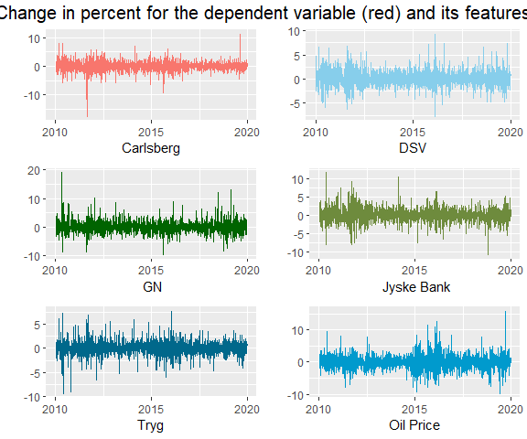

```r
Plot_Collected<-ggarrange(Plot1, Plot2, Plot3, Plot4, Plot5, Plot6, ncol = 2, nrow = 3)
annotate_figure(Plot_Collected, top = text_grob("Change in percent for the dependent variable (red) and its features", size = 15))
```

```r
Plot1 <-  data_Carlsberg_Change %>% ggplot(aes(x = Carlsberg, col= "red") ) +   geom_density()  + theme(legend.position = "none")+ geom_vline(aes(xintercept=mean(Carlsberg)),
            color="darkgrey", linetype="dashed", size=1) + labs(y="" ,x = "Carlsberg") + scale_x_continuous(limits = c(-5,5))+ scale_y_continuous(limits = c(0,0.45))

Plot2 <-  data_Carlsberg_Change  %>% ggplot(aes(x = DSV)) + geom_density(col= "skyblue") + theme(legend.position = "none")+ geom_vline(aes(xintercept=mean(DSV)),
            color="darkgrey", linetype="dashed", size=1)   + labs(y="", x = "DSV")+ scale_x_continuous(limits = c(-5,5))+ scale_y_continuous(limits = c(0,0.45))

Plot3 <-  data_Carlsberg_Change %>%ggplot(aes(x = GN)) + geom_density(col= "darkgreen") + theme(legend.position = "none")+ geom_vline(aes(xintercept=mean(GN)),
            color="darkgrey", linetype="dashed", size=1) + labs(y="", x = "GN")+ scale_x_continuous(limits = c(-5,5))+ scale_y_continuous(limits = c(0,0.45))

Plot4 <-  data_Carlsberg_Change %>% ggplot(aes(x = JyskeBank)) + geom_density(col= "darkolivegreen4") + theme(legend.position = "none")+ geom_vline(aes(xintercept=mean(JyskeBank)),
            color="darkgrey", linetype="dashed", size=1) + labs(y="", x = "Jyske Bank")+ scale_x_continuous(limits = c(-5,5))+ scale_y_continuous(limits = c(0,0.45))

Plot5 <-  data_Carlsberg_Change %>% ggplot(aes(x = Tryg)) + geom_density(col = "deepskyblue4") + theme(legend.position = "none") +geom_vline(aes(xintercept=mean(Tryg)),
            color="darkgrey", linetype="dashed", size=1) + labs(y="", x = "Tryg")+ scale_x_continuous(limits = c(-5,5))+ scale_y_continuous(limits = c(0,0.45))

Plot6 <-  data_Carlsberg_Change %>% ggplot(aes(x =OilPrice)) + geom_density(col = "deepskyblue3") + geom_vline(aes(xintercept=mean(OilPrice)), color="darkgrey", linetype="dashed", size=1) + theme(legend.position = "none")     + labs(y="" ,x = "Oil Price")+ scale_x_continuous(limits = c(-5,5))+ scale_y_continuous(limits = c(0,0.45))
```

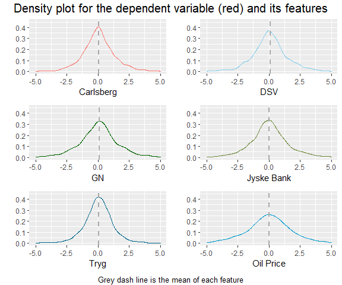

```r
Plot_Collected<-ggarrange(Plot1, Plot2, Plot3, Plot4, Plot5, Plot6, ncol = 2, nrow = 3)
annotate_figure(Plot_Collected, top = text_grob("Density plot for the dependent variable (red) and its features", size = 15),  bottom = text_grob("Grey dash line is the mean of each feature", size = 10))
```

Cleaning the environment from unnecessary data sets.

```r
rm(Plot1, Plot_Baverian, Plot2, Plot3, Plot4, Plot5, Plot6, Plot7, Plot_Collected, data_Carlsberg_plot, data_Carlsberg_Change)
```

## Saving the data set

The Carlsberg data set is now done and ready for forecast. It is saved as a cvs-file and uploaded on [Github](https://github.com/andreasbj77/Master-thesis?fbclid=IwAR1-uXAsXOvRxWwDzpfhzjiqyOhil9E4wklrK03_fRMZhLQ7EYTrooHzTw0)

```r
write_as_csv(data_Carlsberg,"DataCreationCarlsberg.csv")
```

```r
rm(data_Carlsberg)
```